# 失聯移工時間序列資料分析

Tai-Wei Ciou

2022/5/5

## 一、前言

### 台灣失聯移工現狀

台灣於2016年至2021年，平均每月約新增1605.6名失聯移工(勞動部，產業及社福移工－行蹤不明失聯人數)。至2022年2月，全台總計有58581名失聯移工(內政部移民署，失聯移工人數統計)。移工勞動市場受國家高度管制：在供給面上，限制移工居留年限，且聘雇許可需定期更新，加之移工禁止轉換雇主，在勞資權力不對等的雇用關係中，移工較難獲得更好的薪資與勞動條件；於需求面上，許可雇用移工之產業為所謂3D(Dirty, Difficult, Danger)產業，因本國勞工從事意願較低而長期缺工，加之移工雇用受配額管制，合法移工的勞力運用相對缺乏彈性，提供廠商聘雇非法勞動力的動機。供給需求兩造作用下，移工勞動力市場形成黑市，移工「逃跑」可能獲得更佳的薪資與勞動條件(許文源。2001)。然而移工失聯長期下來可能造成許多社會問題，以近年疫情為例，無法追蹤的失聯移工人口並可能成為防疫破口，威脅公共安全。  
為緩解失聯移工問題，勞動部於2016年11月修正發布「雇主聘僱外國人許可及管理辦法」，刪除外籍移工應出國1日後始得再入國工作之規定。過去因移工聘雇許可以三年為期，再次聘雇須移工至少出國一日。由於聘雇新的移工仲介能再次收取牛頭費，重新補充利潤(王宏仁，白朗潔。2007)，仲介因而有動機鼓勵雇主聘用新移工而非續聘；許文源(2001: 166-7)亦對收容所居留之失聯移工進行調查，發現逃跑原因為「任期屆滿，將被遣返」者達12.2%。是以，刪除應出國一日使得再入境工作之規定，應可有效降低失聯移工數量。

本文透過時間序列資料分析，以2016年11月就業服務法「刪除外籍移工應出國1日後始得再入國工作之規定」作為目標政策，評估其對減少失聯移工是否有影響。文章安排如下：第2節講述分析資料之選取；第3節呈現資料模型建構與選取過程，並估計政策效應；第4節考慮資料結構轉變(structure change)之可能再行估計；第六節根據結果提出結論。

## 二、實證資料

本文使用勞動部「產業及社福移工－行蹤不明失聯人數」2010年3月至2022年2月之月資料進行分析，共144項觀察值。 台灣移工政策歷經多次調整，但於2010年3月實施「3K五級制」後，移工雇用更具彈性，移工人數亦顯著增長。在整體移工數量增加的背景下，失聯移工歷年數量亦呈增長趨勢。然觀察失聯移工占整體移工數量之比例，可發現在千分之二到千分之四之間，大致處於同一水準。後續本文對失聯移工比例進行Augmented Dickey-Fuller Test, 發現失聯移工比例乃一穩態(Stationary)資料。本文因此將以失聯移工佔整體移工數量比例做為實現值進行分析。

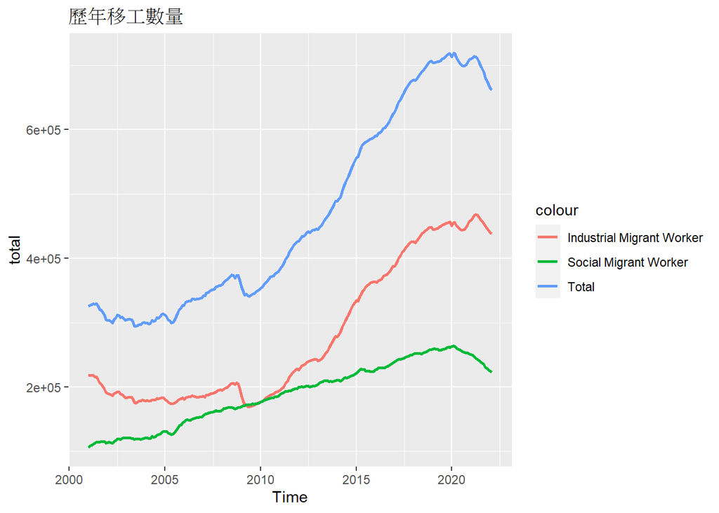

圖2-1：2010年後移工數量逐年增加。

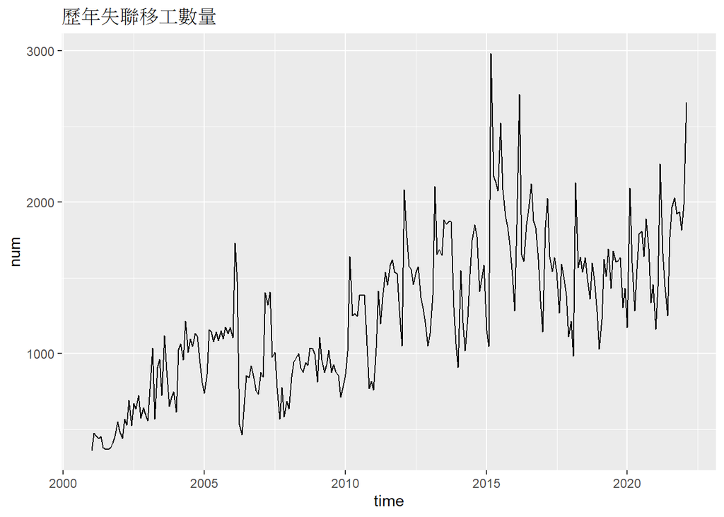

圖2-2：2010年後失聯移工數量逐年增加，原因是整體移工數量亦於2010年後逐年增加。

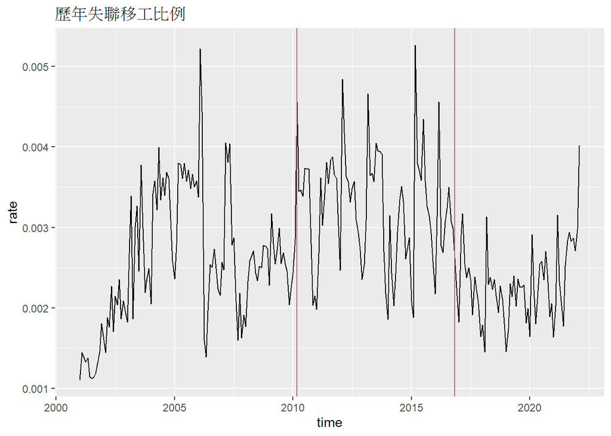

圖2-3：失聯移工數量占整體移工數量之比例變動不大，本文認為失聯移工比例乃是穩態(Stationary)資料。 圖中兩條紅線分別標示出2010年3月實施「3K五級制」與2016年11月「刪除移工應出國一日再入國工作之規定」的時間點。

觀察失聯移工資料的時間曲線圖(Time Plot)，可發現政策前後資料的模式(Pattern)有所不同。圖三兩條紅線分別標示出2010年3月實施「3K五級制」與2016年11月「刪除移工應出國一日再入國工作之規定」的時間點。可以發現兩次政策前後所呈現的曲線圖的平均值與變動程度皆有所不同。後續本文除了對政策進行干預分析(intervention analysis)以評估政策效應，亦考慮資料可能具結構轉變(Structure Changes)性質的條件下進行分析。

由於資料所呈現特性以及考量政策變動對資料的影響，本文認為目標政策前後之移工勞動市場環境迥異，分析時應予以區隔；且2009受金融海嘯影響，政府亦採行數項縮減移工措施(李長泰、張景福。2018)。為避免多餘政策干預影響分析，本文僅採用2010年3月之後的資料進行分析。

## 三 模型選取與干預分析

本節利用2010年3月至2016年10月資料作為模型訓練資料，並使用目標政策後資料—2016年11月至2020年4月—作為驗證資料，評估政策效果。

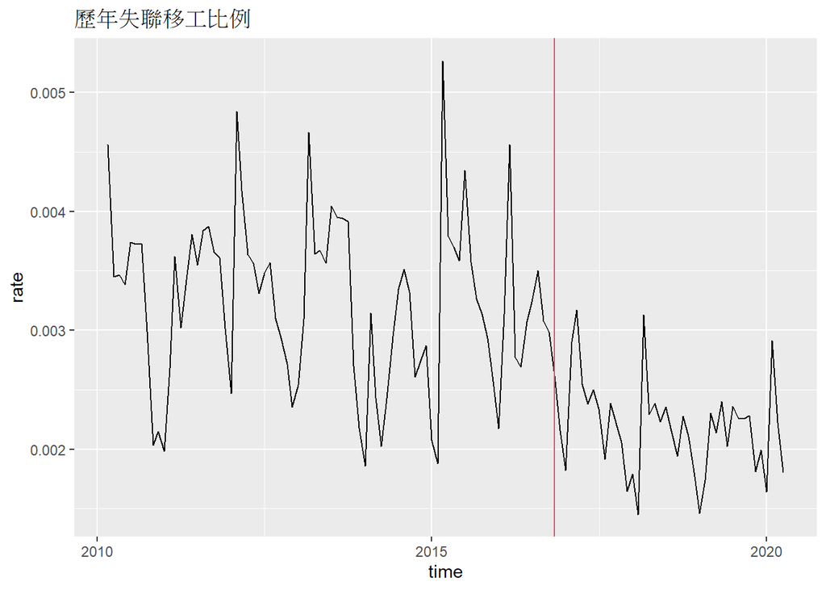

### 初步分析

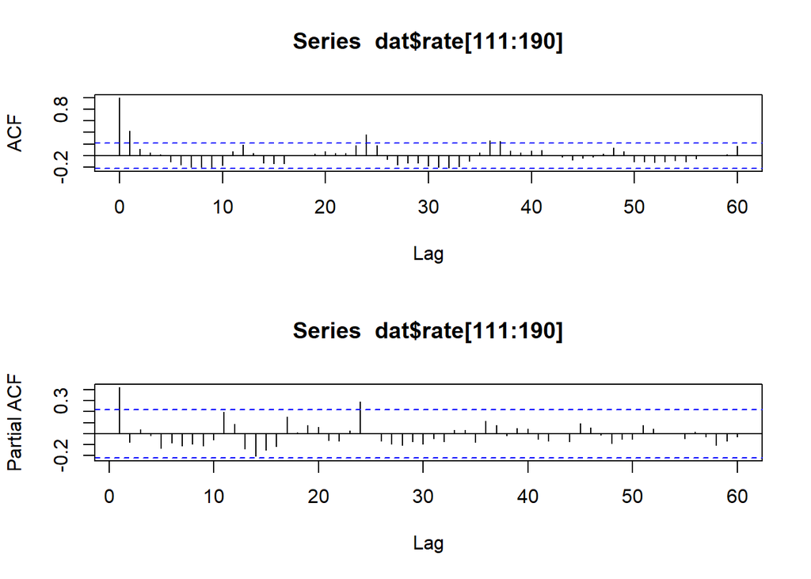

觀察資料之ACF與PACF，可發現ACF呈現 Tail off 走勢，並每隔12期出現相對顯著之自我相關；PACF部分則在落後一期呈現 Cut off 走勢，並同樣每隔12期出現相對顯著之偏自我相關。初步選取$SARIMA(1,0,0)(1,0,1)_{12}$作為資料模型進行估計。

```r
fit1 <-arima(x = dat$rate[111:190],
             order = c(1,0,0),
             seasonal = list(order = c(1,0,1), period = 12))
fit1
```

```
##
## Call:
## arima(x = dat$rate[111:190], order = c(1, 0, 0), seasonal = list(order = c(1,
##     0, 1), period = 12))
##
## Coefficients:
##          ar1    sar1     sma1  intercept
##       0.4229  0.9993  -0.9686     0.0032
## s.e.  0.1012  0.0049   0.1093     0.0003
##
## sigma^2 estimated as 2.467e-07:  log likelihood = 485.6,  aic = -961.19
```

估計結果顯示初步模型大致正確，各係數值皆大於兩個標準差外。

再仔細觀察ACF 與 PACF, 可以發現兩者皆呈現震盪遞減走勢，表示有落後複數期自我相關 的可能。奠基於 $sarima(1,0,0)(1,0,1)_{12}$，於模型各階加一階作為可能遍歷模型之選擇，本文考慮遍歷以下所有模型：

$$sarima(i,0,j)(k,0,l)_{12}\\
i \in\{0,1,2\};\quad j \in \{0,1\};\quad k \in \{0,1,2\};\quad l \in \{0,1,2\}$$

計算結果呈現於表1。

表1：本表依據所遍歷模型之AIC由小到大依序排列，AllSignif欄位顯示是否所有係數皆顯著，0表示否，1表示是。

|  | i | j | k | l | aic | AllSignif |
| --- | --- | --- | --- | --- | --- | --- |
| 54 | 0 | 0 | 0 | 0 | 0.0000 | 0 |
| 24 | 1 | 0 | 2 | 0 | 190.9566 | 0 |
| 25 | 1 | 0 | 2 | 1 | 191.1979 | 0 |
| 34 | 1 | 1 | 2 | 1 | 192.2842 | 0 |
| 33 | 1 | 1 | 2 | 0 | 192.5657 | 0 |
| 42 | 2 | 0 | 2 | 0 | 192.7373 | 0 |
| 43 | 2 | 0 | 2 | 1 | 192.7589 | 0 |
| 23 | 1 | 0 | 1 | 2 | 193.1282 | 0 |
| 26 | 1 | 0 | 2 | 2 | 193.1873 | 0 |
| 32 | 1 | 1 | 1 | 2 | 193.8092 | 0 |
| 16 | 0 | 1 | 2 | 1 | 194.1236 | 0 |
| 35 | 1 | 1 | 2 | 2 | 194.2669 | 0 |
| 51 | 2 | 1 | 2 | 0 | 194.4676 | 0 |
| 41 | 2 | 0 | 1 | 2 | 194.4944 | 0 |
| 44 | 2 | 0 | 2 | 2 | 194.7428 | 0 |
| 15 | 0 | 1 | 2 | 0 | 195.0271 | 0 |
| 14 | 0 | 1 | 1 | 2 | 195.6942 | 0 |
| 22 | 1 | 0 | 1 | 1 | 196.0745 | 1 |

依據上表可以得知，$sarima(1,0,0)(1,0,1)_{12}$為所遍歷模型裡，所有係數皆顯著者中AIC值最小者，與初步模型相同。我們選取此模型作為資料模型。

#### 殘差分析

##### 殘差是否符合常態性假設

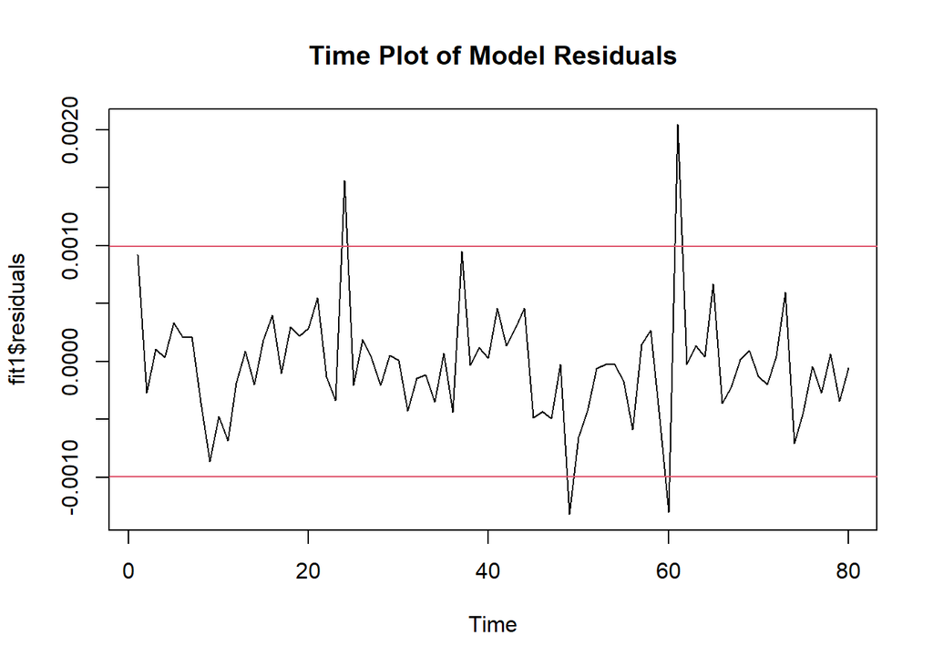

圖3-4:模型殘差時間曲線圖。圖中紅線標示殘差之兩倍標準差位置。

```r
a <- c(abs(fit1$residuals) >= 2*sqrt(fit1$sigma2))
outer1 <- sum(a)/(length(dat$rate[111:190]))
outer1
```

```
## [1] 0.05
```

上述程式碼計算模型估計殘差大於兩倍標準差的觀察值佔所有觀察值個數比例，正好為5%。符合常態性假設。

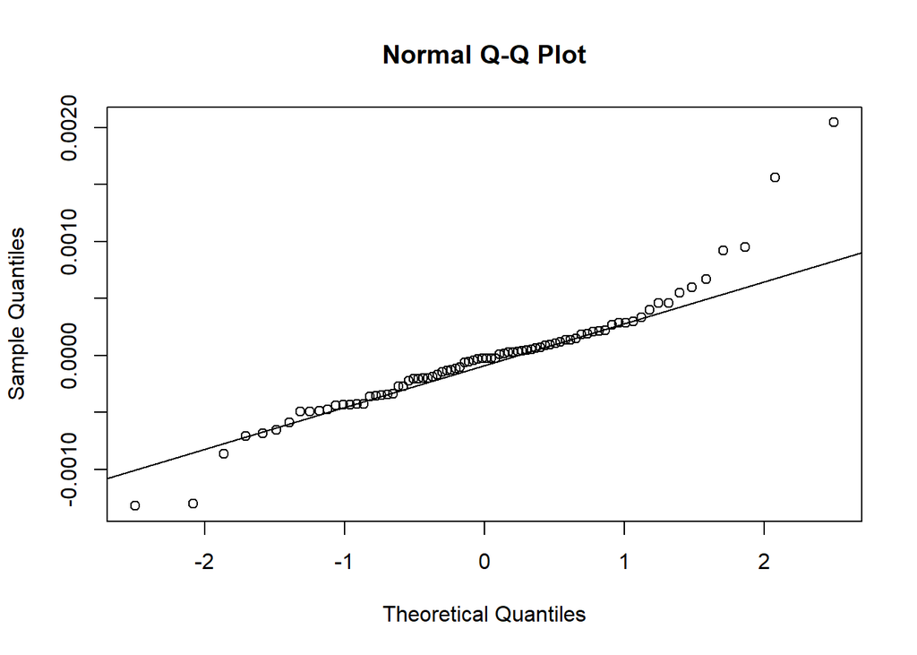

圖3-5:模型殘差之分位圖。極值部分殘差估計值不符合常態分佈。

```
##
##  Jarque Bera Test
##
## data:  fit1$residuals
## X-squared = 68.044, df = 2, p-value = 1.665e-15
```

圖八顯示模型殘差極值偏離。我們對殘差進行Jarque-Bera Test，發現p值遠小於5%，顯示殘差不符合常態分佈。

##### 殘差是否具自我相關

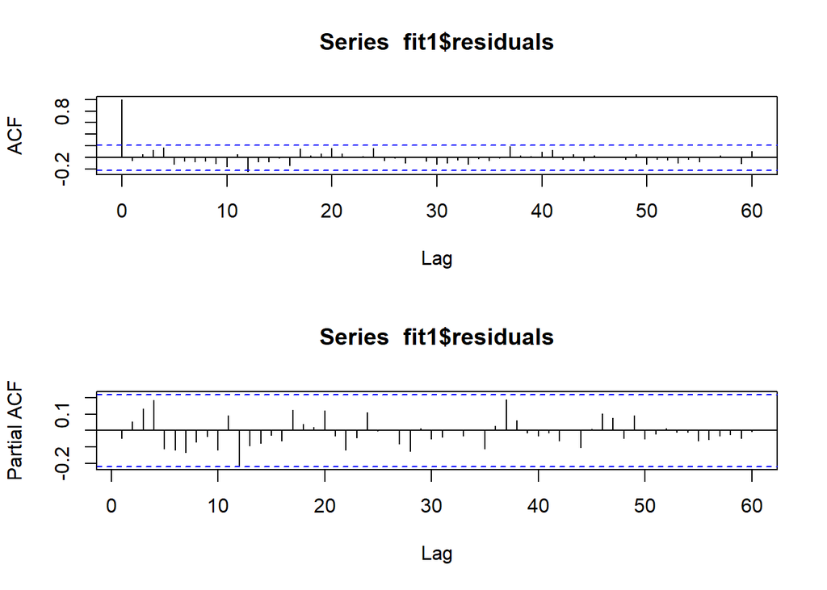

圖3-6：ACF與PACF 顯示模型殘差無顯著自我相關

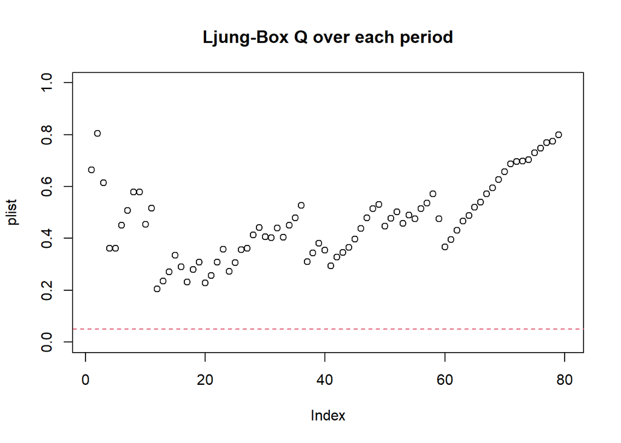

圖3-7：各階 jung-Box’s Q 之 p值皆大於0.05

觀察殘差之ACF和PACF可以發現無顯著自我相關，殘差之Ljung-Box Test結果也顯示同樣結果。

##### 小結

我們最後選取$arima(1,0,0)(1,0,1)_{12}$作為接續干預分析之基礎模型。此模型之估計殘差無自我相關，但在極值部分不符合常態性假設。

### 干預分析(Intervention Analysis)

假設目標政策效果以下述變數呈現

$$\omega_0I_t,$$

其中 $\omega_0$ 是政策效果，且

$$I_t=\left\{
\begin{aligned}
0 &\quad t\leq 190\text{(Nov. 2016)} \\
1 &\quad t > 190 \\
\end{aligned}
\right.$$

我們增加2016年11月至2020年4月之資料，評估此政策效果。

```
##
## Call:
## arima(x = dat$rate[111:232], order = c(1, 0, 0), seasonal = list(order = c(1,
##     0, 1), period = 12), xreg = as.data.frame(dat["treatment"][111:232, ]))
##
## Coefficients:
##          ar1    sar1     sma1  intercept  dat["treatment"][111:232, ]
##       0.3893  0.9989  -0.9650     0.0032                       -1e-03
## s.e.  0.0842  0.0060   0.0924     0.0002                        2e-04
##
## sigma^2 estimated as 2.112e-07:  log likelihood = 754.91,  aic = -1497.83
```

模型大致正確，政策變數呈顯著，各係數在加入政策變數後依然顯著，。

#### 殘差分析

##### 殘差是否符合常態性假設

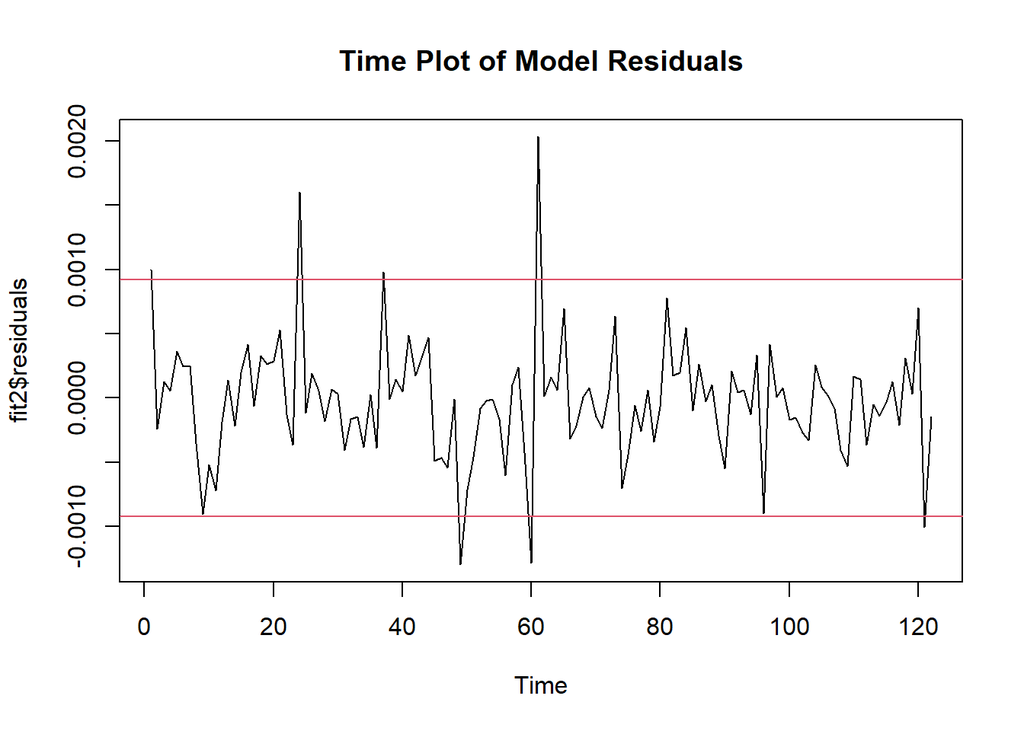

圖3-8:加入政策影響後模型殘差時間曲線圖。圖中紅線標示殘差之兩倍標準差位置。

```r
a <- c(abs(fit2$residuals) >= 2*sqrt(fit2$sigma2))
outer1 <- sum(a)/(length(dat$rate[111:232]))
outer1
```

```
## [1] 0.05737705
```

加入政策效果後估計殘差大於兩倍標準差的觀察值佔所有觀察值個數比例為5.74%，略大於5%。

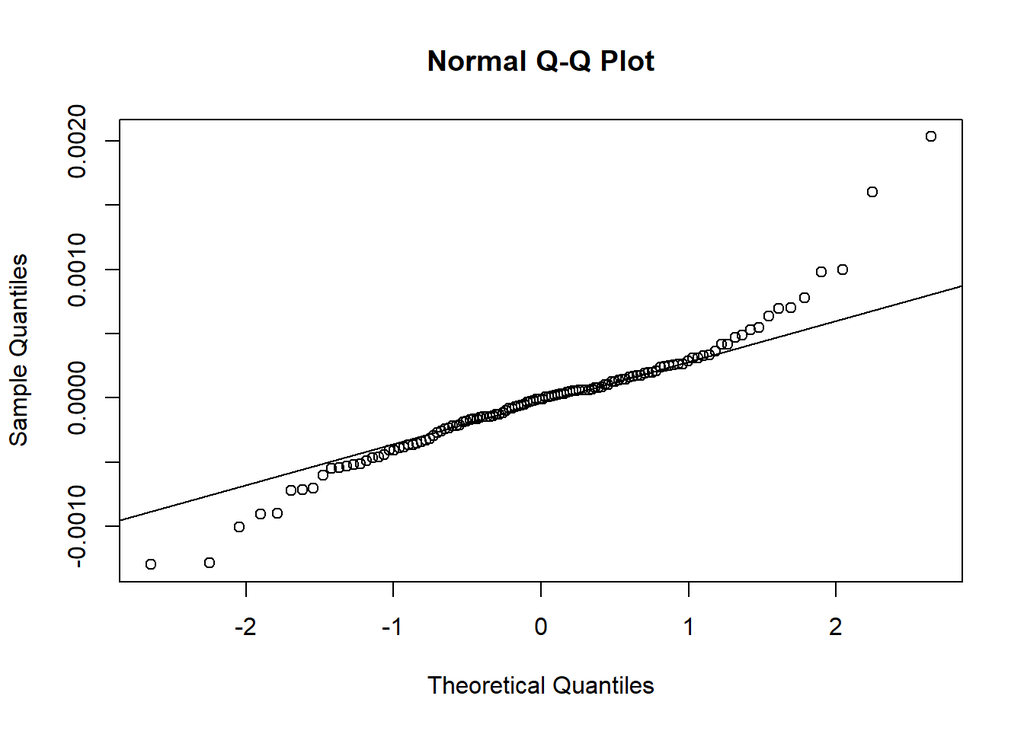

圖3-9:模型殘差之分位圖。極值部分殘差估計值不符合常態分佈。

```
##
##  Jarque Bera Test
##
## data:  fit2$residuals
## X-squared = 88.154, df = 2, p-value < 2.2e-16
```

圖八顯示加入政策效果模型之殘差極值偏離常態。我們對殘差進行Jarque-Bera Test，發現p值遠小於5%，顯示殘差不符合常態分佈。

##### 殘差是否具自我相關

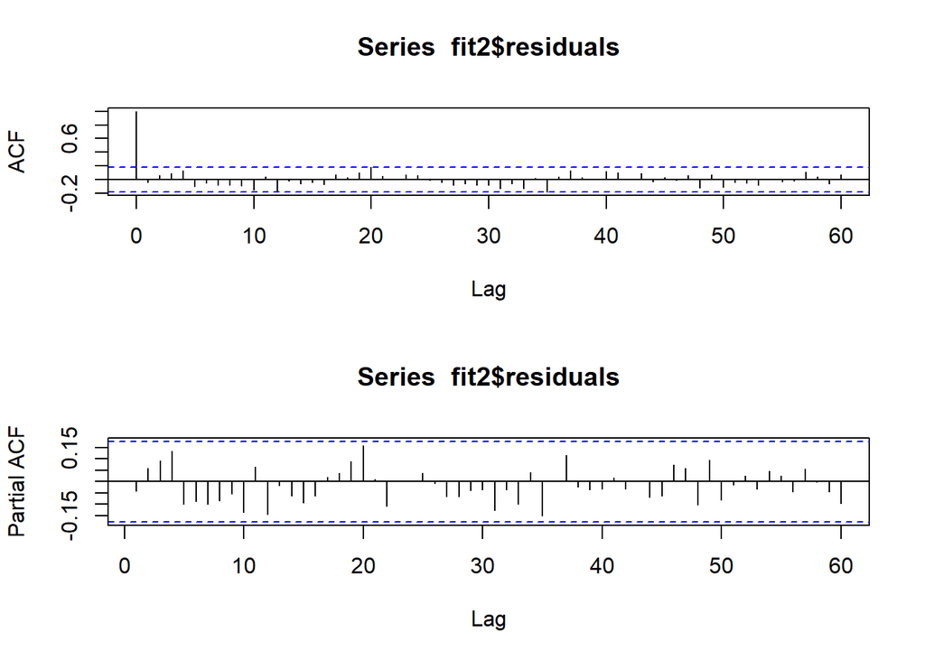

圖3-6：ACF與PACF 顯示模型殘差無顯著自我相關

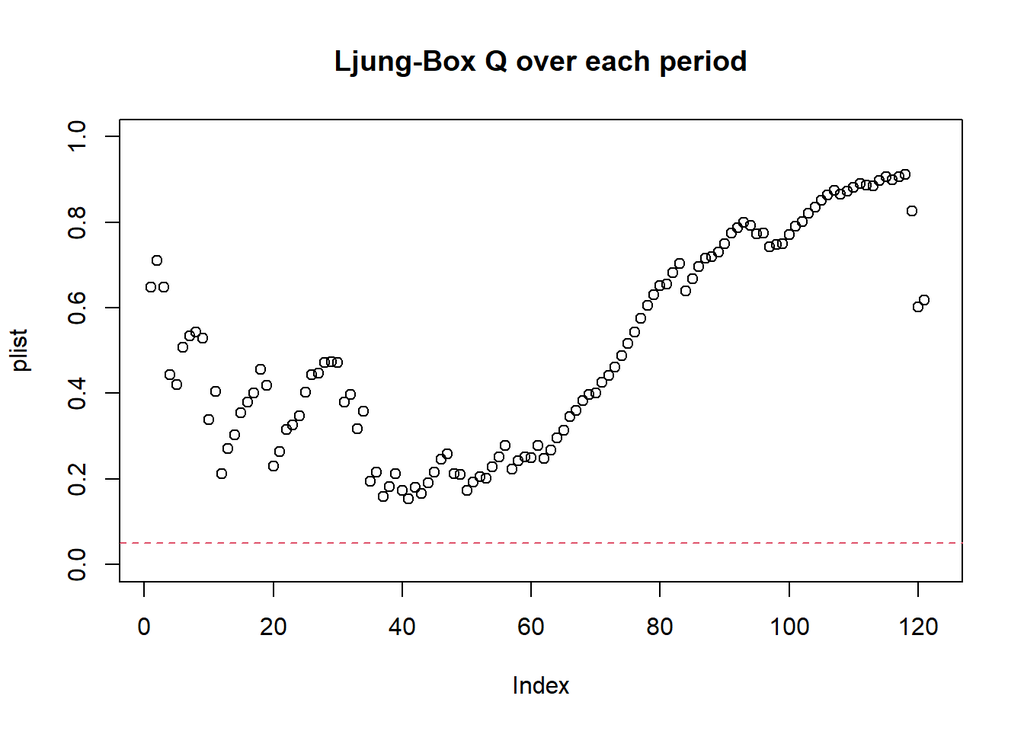

圖3-7：各階 jung-Box’s Q 之 p值皆大於0.05

觀察殘差之ACF和PACF可以發現無顯著自我相關，殘差之Ljung-Box Test結果也顯示相同結果。

##### 小結

依據估計結果，政策效果$\omega_0$約為$-9.95 \times 10^{-4}$。經換算(乘以2010年至2016年平均移工總人數)，政策實施後相較於2010年至2016年，每月減少約479.5名失聯移工。 然而，模型之殘差極值表現不符常態性假設。

## 四、結構轉變

由圖2-3我們可以觀察到目標政策前後，資料時間曲線之模式(Pattern)迥異。本節分別運用政策前後資料估計模型，並利用Chow’s Test 確認是否具結構轉變特性

我們首先對政策前後之資料分別估計模型。我們同樣運用上一節所選擇之$arima(1,0,0)(1,0,1)_{12}$模型進行估計。同時，為了比較與後續進行Chow’s Test 所需，我們亦估計包含政策前後全部時間之資料的模型。

```
##
## Call:
## arima(x = dat$rate[111:190], order = c(1, 0, 0), seasonal = list(order = c(1,
##     0, 1), period = 12))
##
## Coefficients:
##          ar1    sar1     sma1  intercept
##       0.4229  0.9993  -0.9686     0.0032
## s.e.  0.1012  0.0049   0.1093     0.0003
##
## sigma^2 estimated as 2.467e-07:  log likelihood = 485.6,  aic = -961.19
```

```
##
## Call:
## arima(x = dat$rate[191:232], order = c(1, 0, 0), seasonal = list(order = c(1,
##     0, 1), period = 12))
##
## Coefficients:
##          ar1     sar1    sma1  intercept
##       0.1156  -0.1831  0.9999     0.0022
## s.e.  0.1666   0.2569  0.5834     0.0002
##
## sigma^2 estimated as 8.723e-08:  log likelihood = 274.41,  aic = -538.81
```

我們發現以政策實施後資料建立模型除截距項外各項係數皆不顯著，可能是觀察值不足，亦可能是自我相關係數值減少。然無論是政策前後，截距項皆呈顯著，且政策後模型之截距項值較低，與上節失聯移工數量減少之結果相符合。

```
##
##  Jarque Bera Test
##
## data:  fit3.b$residuals
## X-squared = 1.1849, df = 2, p-value = 0.553
```

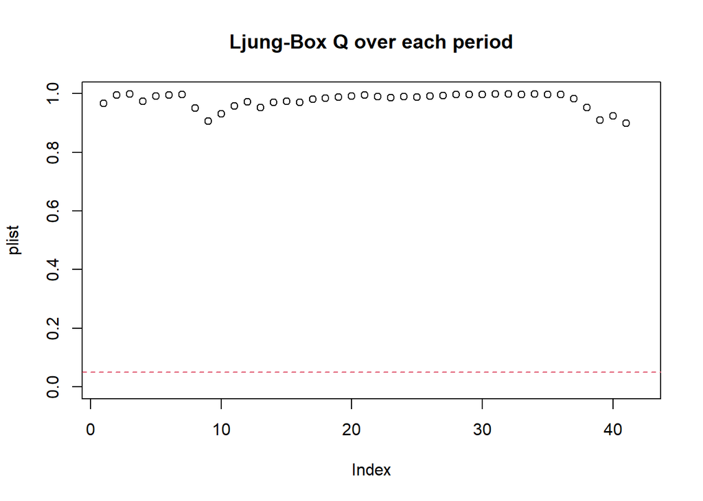

圖4-1：政策後模型殘差各階 jung-Box’s Q 之 p值皆大於0.05

值得注意的是，僅用政策後資料估計之模型通過Ljung-Box Test 和 Jarque-Bera Test，顯示其殘差無自我相關且符合常態性假設。

#### Chow’s Test

令$SSR_0$為包含政策前後全部時間估計模型之殘差平方和，$SSR_1$為政策前估計模型殘差平方和，$SSR_2$為政策後估計模型殘差平方和。$p+1$為包含截距項之變數數量，$T$為資料包含之時間點。

Chow’s Test 之 F 統計量以下式表示：

$$F = \frac{(SSR_0-SSR_1-SSR_2)/(p+1)}{(SSR_1+SSR_2)/(T-2(p+1))} \text{~} F_{(p+1,T-2p-2)}$$

```
## [1] 2.451273
```

```
## [1] 12.718
```

F 統計量為12.718, 大於$F(4,114)$分配之95% critical value 2.451273。顯示失聯移工資料於目標政策實施後確實有結構轉變。

## 五、預測表現

本節比較以下不同模型之預測表現

- 模型1：使用2010年3月至2020年4月資料訓練之模型，無政策效果變數。
- 模型2：使用2010年3月至2020年4月資料訓練之模型，加入政策效果變數$I_t$。
- 模型3：結構轉變模型，僅使用2016年11月政策實施後資料訓練之模型。

上述所有模型皆為$arima(1,0,0)(1,0,1)_{12}$模型。

```r
model1 <-arima(x = dat$rate[111:232],
               order = c(1,0,0),
               seasonal = list(order = c(1,0,1), period = 12))
model2 <-arima(x = dat$rate[111:232],
               order = c(1,0,0),
               seasonal = list(order = c(1,0,1), period = 12),
               xreg = as.data.frame(dat["treatment"][111:232,]))
model3 <- fit3.b

pred1 <- predict(model1, n.ahead = 22)
pred2 <- predict(model2, n.ahead = 22,
                 newxreg = as.data.frame(dat["treatment"][233:254,]))
pred3 <- predict(model3, n.ahead = 22)
```

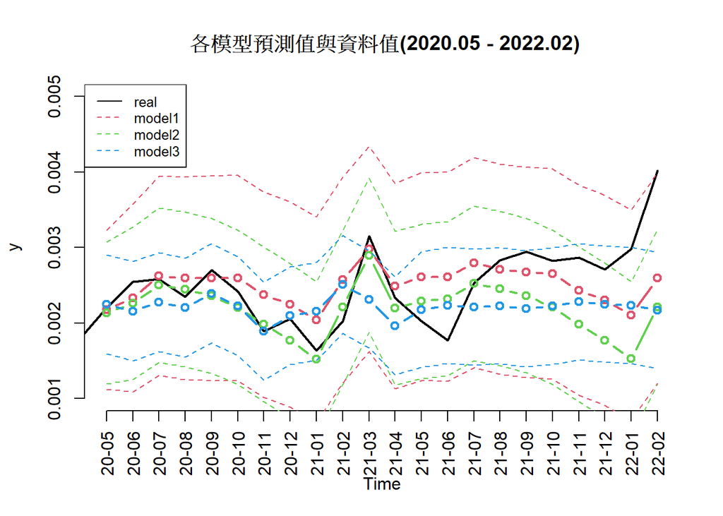

圖5-1：各模型預測表現。圖中實線與圈表示預測值，虛線表示各模型預測值兩倍標準差處

```r
mad1 <- mean(abs(y[233:254]-pred1$pred))
mad2 <- mean(abs(y[233:254]-pred2$pred))
mad3 <- mean(abs(y[233:254]-pred3$pred))
mad1.2 <- mean(abs((y[233:254]-pred1$pred)[1:12]))
mad2.2 <- mean(abs((y[233:254]-pred2$pred)[1:12]))
mad3.2 <- mean(abs((y[233:254]-pred3$pred)[1:12]))
df <- data.frame(cbind(c(mad1,mad2,mad3),c(mad1.2,mad2.2,mad3.2)))
colnames(df) <- c("MAD(May.20 - Feb.22)","MAD(May.20 - Apr.21)")
row.names(df) <- c("Model1","Model2","Model3")
knitr::kable(df)
```

|  | MAD(May.20 - Feb.22) | MAD(May.20 - Apr.21) |
| --- | --- | --- |
| Model1 | 0.0003719 | 0.0002317 |
| Model2 | 0.0004377 | 0.0001793 |
| Model3 | 0.0004620 | 0.0003026 |

我們計算各模型之Mead absolute deviation,MAD，發現模型1給出最小的值。推測可能是模型1是模型中預測值偏高者，疫情後的上升趨勢使其減少了與另外兩個模型的差距。在重新考慮不包含疫情後上升趨勢的資料計算MAD，模型2確是最好的模型。

## 六 結論

本文利用2010年至2022年失聯移工月資料，建立對每月新增失聯移工占整體移工比例的時間序列模型，顯示失聯移工時間序列資料應為一$sarima(1,0,0)(1,0,1)$模型。

本文利用干預分析(Intervention analysis)對於2016年11月勞動部「刪除外籍移工應出國1日後始得再入國工作之規定」之政策效果進行估計。發現該政策對於減少失聯移工之效果統計上顯著。估計結果顯示，相較於2010年3月至2016年10月政策實施前，**該政策每月減少約479.5名失聯移工，是政策實施前每月失聯移工人數的30.7%**，足見政策效果卓著。

本文模型的殘差不符合常態性假設，推測是資料極端值尚存在不明機制。本文猜測，失聯移工現象具同儕效應，當移工身邊出現較多失聯移工，可能增加移工逃跑的機率。因而出現極值「高的很高，低的很低」的現象。另外，亦可發現政策前後資料其變動程度有異，後續亦可考慮廣義線性回歸模型，考慮異質變異數再行估計。